# Statistics in Python: Mann–Whitney *U* Test

⇦ Back

The code on this page uses the `numpy`, `matplotlib` and `scipy` packages. These can be installed from the terminal with:

```bash
$ python3.11 -m pip install numpy
$ python3.11 -m pip install matplotlib
$ python3.11 -m pip install scipy
```

where `python3.11` corresponds to the version of Python you have installed and are using.

# 1 Example Data

This example is taken from Section 12.4 of *Probability and Statistics for Engineers and Scientists* by S M Ross (4th edition, 2009). A fictional experiment designed to test the effectiveness of two different anti-corrosion treatments for metal yielded the following results:

- Treatment 1: 65.2, 67.1, 69.4, 78.2, 74, 80.3
- Treatment 2: 59.4, 72.1, 68, 66.2, 58.5

where the values represent the maximum depth of pits worn into the metal in thousands of a centimetre. This can be hard-codes as a dictionary of lists in Python as follows:

```python
# Raw data
data = {
    'Treatment 1': [65.2, 67.1, 69.4, 78.2, 74, 80.3],
    'Treatment 2': [59.4, 72.1, 68, 66.2, 58.5]
}
```

Here’s what the data looks like graphically:

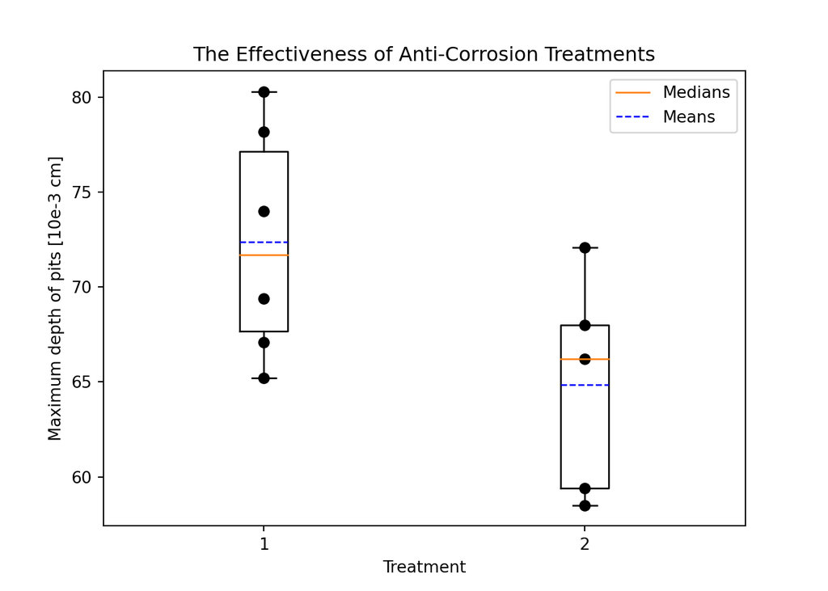

```python
import matplotlib.pyplot as plt
import numpy as np

#
# Plot
#
# Boxplot
meanprops = {'color': 'b'}
bp = plt.boxplot(data.values(), showmeans=True, meanline=True, meanprops=meanprops)
# Scatterplot for treatment 1
y = data['Treatment 1']
plt.scatter(np.zeros(len(y)) + 1, y, c='k')
# Scatterplot for treatment 2
y = data['Treatment 2']
plt.scatter(np.ones(len(y)) + 1, y, c='k')
# Tile and labels
plt.title('The Effectiveness of Anti-Corrosion Treatments')
plt.xlabel('Treatment')
plt.ylabel('Maximum depth of pits [10e-3 cm]')
# Legend
plt.legend([bp['medians'][0], bp['means'][0]], ['Medians', 'Means'])
```

# 2 Choose a Statistical Test

Looking at the data plotted above, the question we want to ask is:

**Is the average amount of wear different between samples given different anti-corrosion treatments?**

If it is, it would suggest that that the effectiveness of the treatments is different.

## 2.1 Parametric vs Non-Parametric

As the sample size in this example dataset is small, **we should choose to do non-parametric statistics** and tweak our research question so that it becomes “is the *median* amount of wear different?”<sup>1</sup>. In other words, are the orange lines in the plot above (the medians) at different heights?

<sup>1</sup>when doing parametric statistics you should use the *mean*; when doing non-parametric statistics you should use the *median*.

## 2.2 Set a Hypothesis

In order to answer the research question (“is the median amount of wear different?”) we now need to formulate it properly as a *null hypothesis* with a corresponding *alternate hypothesis*:

- H<sub>0</sub>: true median amount of wear is the same for both treatments
- H<sub>1</sub>: true median amount of wear is not the same for both treatments

## 2.3 Choose a Test

Now that we have hypotheses, we can follow a statistical test selection process:

- Our data is **continuous** because it is made up of measurements that are numbers (not discrete categories or ranks)
- We are interested in the **difference** between the amount of wear in one group compared to the other (not the *relationship* between the amount of wear and something else)
- Specifically, we are interested in the difference of the **average** (median) amount of wear (not the *variance* in the amount of wear)
- We have **two groups** because there are two treatments being compared
- As discussed above, we are doing **non-parametric statistics**
- Our measurements are **independent** of each other: the amount that one sample corrodes does not affect how much another sample corrodes

Looking at the flowchart below tells us that we should thus be using the Mann-Whitney *U* test to test our hypothesis:

[interactive chart not shown]

# 3 Mann-Whitney *U* Test

The SciPy package makes it incredibly easy to perform the test: just use the `mannwhitneyu()` function!

```python
from scipy.stats import mannwhitneyu

# Perform the Mann-Whitney U test
statistic, pvalue = mannwhitneyu(data['Treatment 1'], data['Treatment 2'])

print(f'Mann-Whitney U test: U = {int(statistic)}, p = {pvalue:6.4f}')
```

```
## Mann-Whitney U test: U = 24, p = 0.1255
```

## 3.1 Interpreting the Result

This *p*-value is large (>0.05), which means that we fail to reject H<sub>0</sub> and conclude that there is not a statistically significant difference between the two treatments (*p* > 0.05).

Often, you will see this type of result reported using asterisks to indicate the significance level (α) associated with it. Additionally, if the *p*-value is very small it’s usually just reported as “<0.001” rather than as an exact value. Here are functions to add in this formatting (not that it’s relevant in this example!):

```python
def get_significance(p):
    """Returns the significance of a p-values as a string of stars."""
    if p <= 0.001:
        return ' (***)'
    elif p <= 0.01:
        return ' (**)'
    elif p <= 0.05:
        return ' (*)'
    elif p <= 0.1:
        return ' (.)'
    else:
        return ''


def round_p_value(p):
    """Round a small p-value so that it is human-readable."""
    if p < 0.001:
        return '<0.001'
    else:
        return f'{p:5.3}'


p_rounded = round_p_value(pvalue)
significance = get_significance(pvalue)
print(f'The p-value is {p_rounded}{significance}')
```

```
## The p-value is 0.126
```

# 4 Can’t Get Enough?

This page showed one method of calculating the Mann-Whitney test which, in my opinion, is the best for practical use. However, if you’re interested in doing a deep dive into how the test works and variations on the method used by SciPy’s `mannwhitneyu()` by default, take a look here.

If you’re interested in adding significance bars to boxplots after having used the Mann-Whitney test to find a significant difference, look over here.

⇦ Back